# Data Mining HW2

Cheng Zhong 16307110259

2019年3月25日

- **设置工作环境**

```r
cat("\014");rm(list=ls()) ##清除工作环境
```

```r
setwd("E:\\Rdata") # 设置工作目录
zhihu <- read.csv("zhihu.csv",,stringsAsFactors =  FALSE,header = T) # 读入待处理文件
```

这里需要注意的是，在文件中第一行第一列为空值，在读入时会产生列名与列数不匹配的情况，故这里将其值设置为“序号”

- **任务一**

查看数据的大致情况

```r
summary(zhihu)
```

```
##       序号           姓名                性别            回答数
##  Min.   :    5   Length:1918        Min.   :0.0000   Min.   :    1.0
##  1st Qu.: 3333   Class :character   1st Qu.:0.0000   1st Qu.:   21.0
##  Median : 7302   Mode  :character   Median :0.0000   Median :   64.0
##  Mean   : 7780                      Mean   :0.2096   Mean   :  209.7
##  3rd Qu.:11811                      3rd Qu.:0.0000   3rd Qu.:  183.0
##  Max.   :17518                      Max.   :2.0000   Max.   :16199.0
##      提问数            专栏数          分享数            点赞数
##  Min.   :   0.00   Min.   :0.000   Min.   :  0.000   Min.   :      1.0
##  1st Qu.:   0.00   1st Qu.:0.000   1st Qu.:  0.000   1st Qu.:    649.2
##  Median :   2.00   Median :1.000   Median :  0.000   Median :   3915.5
##  Mean   :  13.01   Mean   :0.804   Mean   :  4.647   Mean   :  25474.1
##  3rd Qu.:   7.00   3rd Qu.:1.000   3rd Qu.:  1.000   3rd Qu.:  18015.2
##  Max.   :1754.00   Max.   :8.000   Max.   :284.000   Max.   :1460757.0
##      感谢数           行业               公司               职业
##  Min.   :     1   Length:1918        Length:1918        Length:1918
##  1st Qu.:   128   Class :character   Class :character   Class :character
##  Median :   726   Mode  :character   Mode  :character   Mode  :character
##  Mean   :  4917
##  3rd Qu.:  3559
##  Max.   :250787
##    毕业院校             专业           是否备注公众号
##  Length:1918        Length:1918        Length:1918
##  Class :character   Class :character   Class :character
##  Mode  :character   Mode  :character   Mode  :character
##
##
##
##      关注数           被关注数
##  Min.   :    0.0   Min.   :     1
##  1st Qu.:   24.0   1st Qu.:   483
##  Median :   84.5   Median :  2240
##  Mean   :  237.4   Mean   : 16429
##  3rd Qu.:  217.2   3rd Qu.:  9360
##  Max.   :15837.0   Max.   :808142
```

- **任务二**

将“被关注数”作为因变量，使用柱状图对其进行描述性分析，先尝试对原始变量画图，再尝试对“对数被关注数”画图

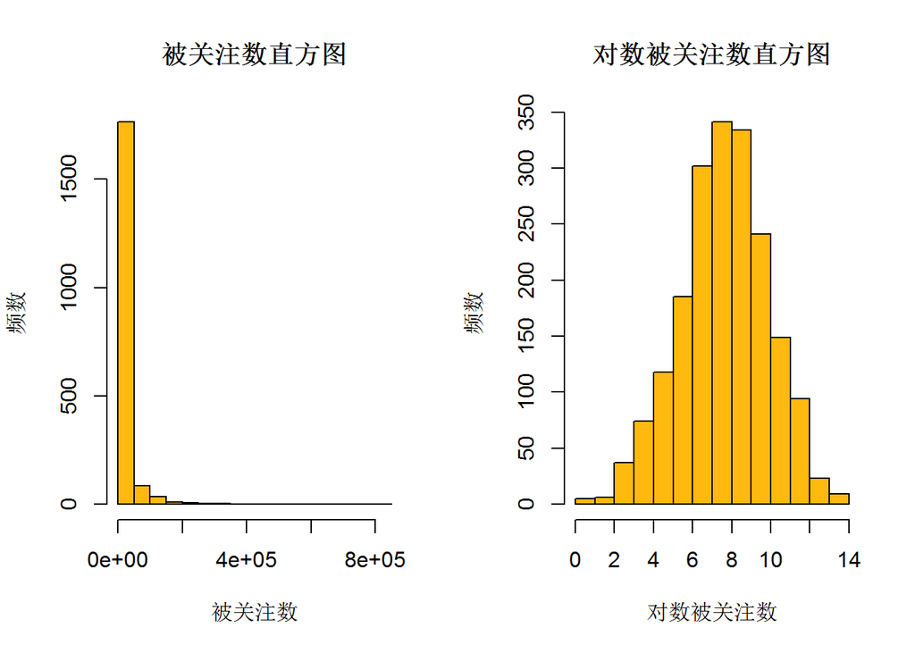

```r
#MissionII
par(mfrow = c(1,2))
hist(zhihu$"被关注数",ylab ="频数",xlab = "被关注数" ,col = "darkgoldenrod1",main = "被关注数直方图")
hist(log(zhihu$"被关注数"),ylab ="频数",xlab = "对数被关注数" ,col = "darkgoldenrod1",main = "对数被关注数直方图")
```

从图中可以看出，对被关注数原始数据画图时，大部分的数据都堆积在较低的区域中，不容易看出数据的分布情况；对“对数被关注数”画图时，数据的分布较为平均，可以看出样本中大多数用户被关注数的对数介于5-10之间。

- **任务三**

- **1.所在公司**

查看不同公司的出现次数,使用箱线图查看是否是BAT与对数被关注数的关系

```r
zhihu[,"log被关注数"] <- log(zhihu[,"被关注数"])
head(sort(table(zhihu$"公司"),decreasing = TRUE),n=20) #先取出公司名出现的次数，随后排序并输出前20项#
```

```
##
##      阿里巴巴集团              腾讯              谷歌              百度
##                21                21                17                13
##              知乎          清华大学          Facebook        University
##                 9                 8                 6                 6
## 微软（Microsoft）       (University      ThoughtWorks          创业公司
##                 6                 5                 5                 5
##              网易          自由职业            NVIDIA          Research
##                 5                 5                 4                 4
##          北京大学            互联网        律师事务所            淘宝网
##                 4                 4                 4                 4
```

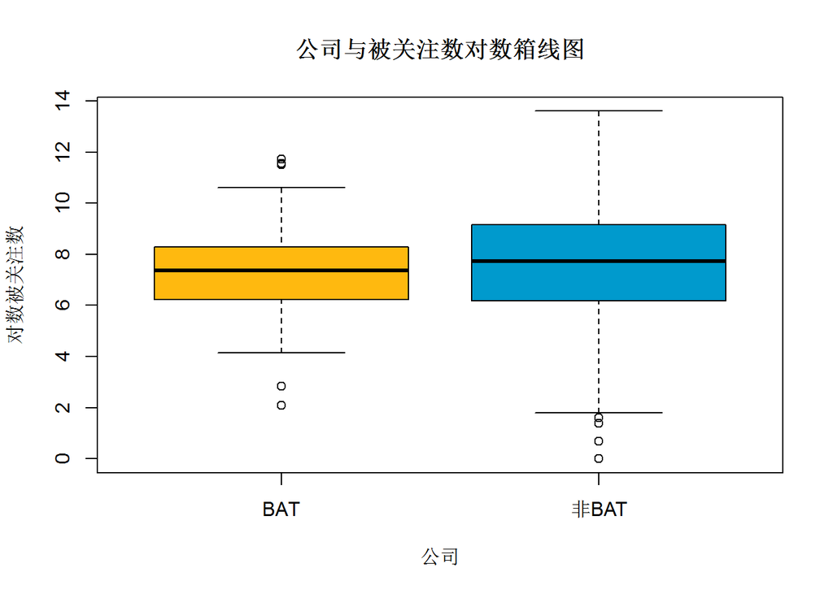

```r
zhihu$BAT = 1
zhihu$BAT[zhihu$"公司"=="阿里巴巴集团"|zhihu$"公司"=="腾讯"|zhihu$"公司"=="百度"] = 0
# 将公司名作为“是否为BAT”的哑变量
par(mfrow = c(1,1))
boxplot(zhihu$"log被关注数" ~ zhihu$BAT,main = "公司与被关注数对数箱线图", ylab = "对数被关注数", xlab = "公司", col = c("darkgoldenrod1","deepskyblue3"),names = c("BAT","非BAT"))# 将“是否为BAT”对“对数被关注数”作图
```

从图中看出，公司是否为BAT对知乎大V被关注数的对数没有明显影响，相应的，我们对知乎用户的职业也进行类似的分析。

- **2.职业**

```r
#与上文类似
head(sort(table(zhihu$职业),decreasing = TRUE),n=20)
```

```
##
##      创始人         CEO  联合创始人    产品经理          of    (Google)
##         101          61          26          22          19          17
##      合伙人  前端工程师    产品总监      工程师         CTO    Software
##          15          15          12          12          11          11
##     Founder        打杂 (University    Research        博士  软件工程师
##          10          10           9           9           9           9
##  博士生在读        记者
##           8           8
```

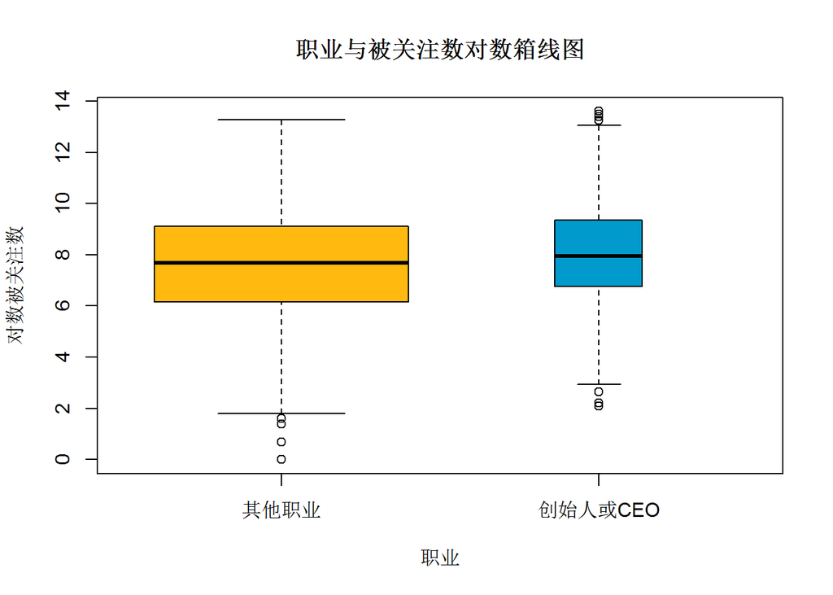

```r
zhihu$"创始人" = 0
zhihu$"创始人"[zhihu$"职业"=="创始人"|zhihu$"职业"=="联合创始人"|zhihu$"职业"=="CEO"|zhihu$"职业"=="合伙人"] = 1
boxplot(zhihu$"log被关注数" ~ zhihu$创始人,names = c("其他职业","创始人或CEO"),main = "职业与被关注数对数箱线图", ylab = "对数被关注数", xlab = "职业", col = c("darkgoldenrod1","deepskyblue3"),varwidth = TRUE)
```

从图中可以看出，总体上职业为创始人或CEO的会比其他职业的人群更加受人关注，最后我们对知乎大V的毕业院校也进行这样的分析。我们首先查看频率前20的毕业院校，根据数据的特点将毕业院校划分为：清北复交浙与非清北复交浙

```r
head(sort(table(zhihu$"毕业院校"),decreasing = TRUE),n=20)
```

```
##
##            北京大学            清华大学            浙江大学
##                  65                  63                  42
##            复旦大学          University        上海交通大学
##                  37                  34                  26
##            南京大学        华中科技大学            同济大学
##                  21                  17                  17
##            武汉大学        中国传媒大学    中山大学（SYSU）
##                  17                  16                  16
##        北京师范大学        哥伦比亚大学        中国人民大学
##                  15                  15                  15
##    北京航空航天大学 北京理工大学（BIT）            南开大学
##                  14                  13                  13
##        电子科技大学      卡内基梅隆大学
##                  12                  12
```

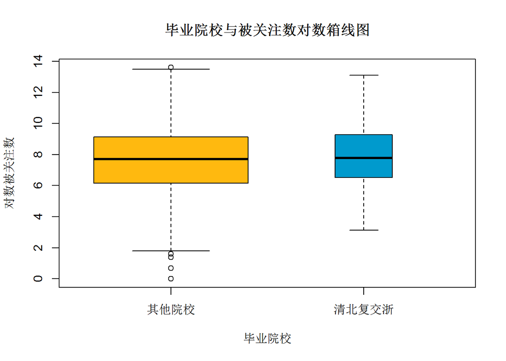

```r
zhihu$"清北复交浙" <- 0
zhihu$"清北复交浙"[zhihu$"毕业院校"=="北京大学"|zhihu$"毕业院校"=="清华大学"|zhihu$"毕业院校"=="浙江大学"|zhihu$"毕业院校"=="复旦大学"|zhihu$"毕业院校"=="上海交通大学"] <- 1
boxplot(zhihu$"log被关注数" ~ zhihu$"清北复交浙", names = c("其他院校","清北复交浙"),main = "毕业院校与被关注数对数箱线图", ylab = "对数被关注数", xlab = "毕业院校", col = c("darkgoldenrod1","deepskyblue3"),varwidth = TRUE)
```

- **任务四**

我们对提问数进行分析，首先查看提问数的分布情况。

```r
summary(zhihu$"提问数")
```

```
##    Min. 1st Qu.  Median    Mean 3rd Qu.    Max.
##    0.00    0.00    2.00   13.01    7.00 1754.00
```

故提问数的四分之三位点为 7.00 , 我们以此作为阈值将提问数离散化为“低问”和“高问”两个区间，随即使用箱线图查看提问情况与对数被关注数的关系。

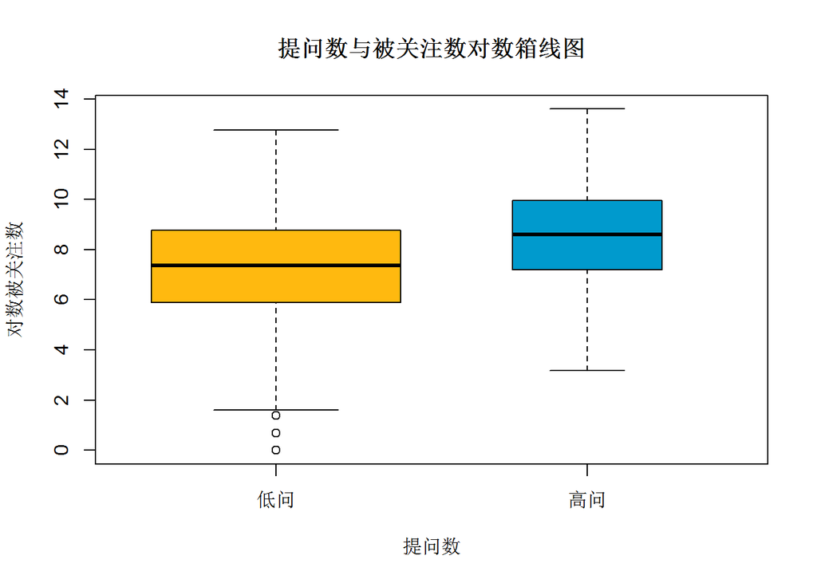

```r
zhihu$"提问等级" <- 1
zhihu$"提问等级"[zhihu$"提问数" < 7.00] <- 0
boxplot(zhihu$"log被关注数" ~ zhihu$"提问等级",names = c("低问","高问"),main = "提问数与被关注数对数箱线图", ylab = "对数被关注数", xlab = "提问数", col = c("darkgoldenrod1","deepskyblue3"),varwidth = TRUE)
```

可以看出，在知乎大V群体中，提问数为“高问”的群体受到的关注更多，也可以理解为在知乎社区更活跃的大V受到的关注更多。

- **任务五**

- 构造其他衍生自变量，“点赞比”“感谢比”和“分享比”

```r
zhihu$"点赞回答比" <- zhihu$"点赞数" / zhihu$"回答数"
zhihu$"感谢回答比" <- zhihu$"感谢数" / zhihu$"回答数"
zhihu$"分享回答比" <- zhihu$"分享数" / zhihu$"回答数"
zhihu$"点赞比"  <- 0
zhihu$"感谢比"  <- 0
zhihu$"分享比"  <- 0
zhihu$"点赞比"[zhihu$"点赞回答比" > 100] <- 1
zhihu$"感谢比"[zhihu$"感谢回答比" > 10] <- 1
zhihu$"分享比"[zhihu$"分享回答比" > 0] <- 1
```

- **任务六**

以“对数被关注数”为因变量，建立线性回归模型

```r
fit <- lm(log被关注数 ~ 性别 + BAT + 创始人 + 清北复交浙 + 提问数 + 专栏数 + 回答数 +  感谢比 + 点赞比 + 分享比, data = zhihu) #建立线性回归模型
summary(fit) # 显示模型概况
```

```
##
## Call:
## lm(formula = log被关注数 ~ 性别 + BAT + 创始人 + 清北复交浙 +
##     提问数 + 专栏数 + 回答数 + 感谢比 + 点赞比 + 分享比, data = zhihu)
##
## Residuals:
##      Min       1Q   Median       3Q      Max
## -10.1315  -0.9395   0.0555   1.0194   5.3865
##
## Coefficients:
##               Estimate Std. Error t value Pr(>|t|)
## (Intercept)  5.453e+00  2.147e-01  25.400  < 2e-16 ***
## 性别        -2.983e-01  8.012e-02  -3.724 0.000202 ***
## BAT          1.785e-01  2.138e-01   0.835 0.404031
## 创始人       2.604e-01  1.164e-01   2.236 0.025473 *
## 清北复交浙   3.848e-01  1.090e-01   3.530 0.000426 ***
## 提问数       1.491e-03  5.166e-04   2.886 0.003952 **
## 专栏数       5.358e-01  3.815e-02  14.044  < 2e-16 ***
## 回答数       7.878e-04  6.298e-05  12.509  < 2e-16 ***
## 感谢比       1.611e+00  9.473e-02  17.009  < 2e-16 ***
## 点赞比       9.554e-01  9.954e-02   9.598  < 2e-16 ***
## 分享比       6.866e-01  7.981e-02   8.604  < 2e-16 ***
## ---
## Signif. codes:  0 '***' 0.001 '**' 0.01 '*' 0.05 '.' 0.1 ' ' 1
##
## Residual standard error: 1.555 on 1907 degrees of freedom
## Multiple R-squared:  0.519,  Adjusted R-squared:  0.5165
## F-statistic: 205.8 on 10 and 1907 DF,  p-value: < 2.2e-16
```